# color_early_late_setaria_21115

malia gehan

February 11, 2015

```r
library(ggplot2)
library(pls)
dir<-"~/Desktop/r/"
setwd(dir)
```

**Set the planting date**

```r
# Planting date
planting_date = as.POSIXct("2013-11-26")
```

**Read in the R,G,B color data and merge the tables**

```r
green1<-read.table("vis_signal_green_10-20-2014_19:23:58.txt", sep=',', header=TRUE)
blue1<-read.table("vis_signal_blue_10-20-2014_19:23:58.txt", sep=',', header=TRUE)
red1<-read.table("vis_signal_red_10-20-2014_19:23:58.txt",sep=',', header=TRUE)

format_data=function(data){
  # Treatment column
  data$treatment <- NA
  data$treatment[grep("AA", data$barcode)] <- 100
  data$treatment[grep("AB", data$barcode)] <- 0
  data$treatment[grep("AC", data$barcode)] <- 0
  data$treatment[grep("AD", data$barcode)] <- 33
  data$treatment[grep("AE", data$barcode)] <- 66

  data$genotype <- NA
  data$genotype[grep("p1", data$barcode)] <- 'A10'
  data$genotype[grep("p2", data$barcode)] <- 'B100'
  data$genotype[grep("r1", data$barcode)] <- 'R20'
  data$genotype[grep("r2", data$barcode)] <- 'R70'
  data$genotype[grep("r3", data$barcode)] <- 'R98'
  data$genotype[grep("r4", data$barcode)] <- 'R102'
  data$genotype[grep("r5", data$barcode)] <- 'R128'
  data$genotype[grep("r6", data$barcode)] <- 'R133'
  data$genotype[grep("r7", data$barcode)] <- 'R161'
  data$genotype[grep("r8", data$barcode)] <- 'R187'

  data=data[grep('000A',data$barcode, invert=TRUE),]

  return(data)
}

green1<-format_data(green1)
blue1<-format_data(blue1)
red1<-format_data(red1)
g<-as.data.frame(green1)
b<-as.data.frame(blue1)
r<-as.data.frame(red1)
gb1<-merge(g,b,by=c("date_time","frame","barcode", "treatment","genotype","day"))
rgb2<-merge(gb1,r, by=c("date_time","frame","barcode", "treatment","genotype", "day"))
rgb1=subset(rgb2, select=-c(day, date_time, frame, barcode, treatment, genotype))

rgb_data<-data.frame(rgb2=I(as.matrix(rgb1)),treatment=rgb2$treatment,genotype=rgb2$genotype,date_time=rgb2$date_time, day=as.integer(rgb2$day))
```

**Read in the shapes data and merge it with the RGB data**

```r
shapes_table<-read.table("vis_snapshots.txt",sep='\t', header=TRUE)
shapes_table$barcode=shapes_table$plant_id
shapes_table$date_time=shapes_table$datetime

rgb_shapes<-merge(rgb2,shapes_table,by=c("date_time","barcode"))
rgb_shapes$day=as.integer(rgb_shapes$day)
```

**Subset the shape-RGB data**

```r
#Day 6 and 7 of the experiment is day 17 and 18 after planting
day17_18<-rgb_shapes[(rgb_shapes$treatment==100|rgb_shapes$treatment==33)& (rgb_shapes$genotype=='A10') & (rgb_shapes$day==6 |rgb_shapes$day==7),]
#Day 14 and 15 of the experiment is day 14 and 15 after planting
day25_26<-rgb_shapes[(rgb_shapes$treatment==100|rgb_shapes$treatment==33)& (rgb_shapes$genotype=='A10') & (rgb_shapes$day==14 |rgb_shapes$day==15),]
```

**Format the RGB data for PCA**

```r
pca_format=function(data){
  data_sub=subset(data, select=-c(extent_x, extent_y,day,frame,barcode,genotype,treatment,date_time,plant_id,datetime,sv_area,tv_area,solidity,perimeter,centroid_x,centroid_y,longest_axis,height_above_bound,height_below_bound,above_bound_area, percent_above_bound_area,below_bound_area,percent_below_bound_area,outlier,boundary_line))
  return(data_sub)
}

pca_nonzero=function(data_sub){
  col_sum=colSums(data_sub)
  channel_data=data_sub[,col_sum!=0]
  return(channel_data)
}

go_pca=function(channel_data){
  channel_pca=prcomp(channel_data,center=TRUE, scale=TRUE)
}
```

**PCA on 17-18 DAP RGB Data**

```r
############# Day  17 and 18 after planting for A10 ###############

day17_18_channel=pca_format(day17_18)
day17_18_data=pca_nonzero(day17_18_channel)
day17_18_pca=go_pca(day17_18_data)
summary(day17_18_pca)
```

```
## Importance of components:
##                            PC1     PC2     PC3     PC4    PC5     PC6
## Standard deviation     17.7478 10.9211 7.57457 6.49447 4.3727 3.79496
## Proportion of Variance  0.4694  0.1777 0.08551 0.06286 0.0285 0.02146
## Cumulative Proportion   0.4694  0.6472 0.73268 0.79554 0.8240 0.84550
##                            PC7     PC8     PC9    PC10    PC11    PC12
## Standard deviation     3.65674 2.94622 2.79090 2.55283 2.49629 2.38997
## Proportion of Variance 0.01993 0.01294 0.01161 0.00971 0.00929 0.00851
## Cumulative Proportion  0.86543 0.87836 0.88997 0.89968 0.90897 0.91748
##                           PC13    PC14    PC15    PC16    PC17    PC18
## Standard deviation     2.31908 2.23176 2.16304 1.92595 1.89173 1.81601
## Proportion of Variance 0.00802 0.00742 0.00697 0.00553 0.00533 0.00491
## Cumulative Proportion  0.92550 0.93292 0.93989 0.94542 0.95076 0.95567
##                           PC19    PC20   PC21    PC22   PC23    PC24
## Standard deviation     1.68289 1.63245 1.5106 1.46844 1.3956 1.36786
## Proportion of Variance 0.00422 0.00397 0.0034 0.00321 0.0029 0.00279
## Cumulative Proportion  0.95989 0.96386 0.9673 0.97048 0.9734 0.97617
##                           PC25    PC26    PC27   PC28    PC29    PC30
## Standard deviation     1.29821 1.25671 1.25156 1.1598 1.10669 1.06345
## Proportion of Variance 0.00251 0.00235 0.00233 0.0020 0.00183 0.00169
## Cumulative Proportion  0.97868 0.98103 0.98337 0.9854 0.98720 0.98888
##                           PC31    PC32    PC33    PC34    PC35    PC36
## Standard deviation     1.05912 0.99684 0.97205 0.94046 0.91325 0.86838
## Proportion of Variance 0.00167 0.00148 0.00141 0.00132 0.00124 0.00112
## Cumulative Proportion  0.99055 0.99204 0.99344 0.99476 0.99600 0.99713
##                           PC37    PC38    PC39      PC40
## Standard deviation     0.85700 0.80432 0.73840 7.882e-15
## Proportion of Variance 0.00109 0.00096 0.00081 0.000e+00
## Cumulative Proportion  0.99822 0.99919 1.00000 1.000e+00
```

```r
day17_18_scores<-as.data.frame(day17_18_pca$x)
day17_18_scores$treatment=day17_18$treatment
day17_18_scores$genotype=day17_18$genotype
day17_18_scores$date_time=day17_18$date_time
day17_18_scores$day=day17_18$day
day17_18_scores$barcode=day17_18$barcode
day17_18_scores$sv_area=day17_18$sv_area
day17_18_scores$height_above_bound=day17_18$height_above_bound

cor.test(day17_18_scores$treatment, day17_18_scores$PC1, method="spearman")
```

```
##
##  Spearman's rank correlation rho
##
## data:  day17_18_scores$treatment and day17_18_scores$PC1
## S = 12845.98, p-value = 0.2043
## alternative hypothesis: true rho is not equal to 0
## sample estimates:
##        rho
## -0.2050641
```

```r
cor.test(day17_18_scores$treatment, day17_18_scores$PC2, method="spearman")
```

```
##
##  Spearman's rank correlation rho
##
## data:  day17_18_scores$treatment and day17_18_scores$PC2
## S = 11619.7, p-value = 0.5806
## alternative hypothesis: true rho is not equal to 0
## sample estimates:
##         rho
## -0.09002814
```

```r
rgb17_18_treatment<-data.frame(rgb=I(as.matrix(day17_18_channel)),treatment=day17_18$treatment,genotype=day17_18$genotype,date_time=day17_18$date_time, day=day17_18$day)
a10_17_18_treatment<-pcr(treatment~rgb,data=rgb17_18_treatment)
summary(a10_17_18_treatment)
```

```
## Data:    X dimension: 40 768
##  Y dimension: 40 1
## Fit method: svdpc
## Number of components considered: 39
## TRAINING: % variance explained
##             1 comps  2 comps  3 comps  4 comps  5 comps  6 comps  7 comps
## X          40.19995  64.0329  75.9726   82.348   86.823   89.386   91.536
## treatment   0.04865   0.4494   0.6911    1.327    1.346    6.826    6.866
##            8 comps  9 comps  10 comps  11 comps  12 comps  13 comps
## X           92.737   93.668     94.48     95.21     95.84     96.41
## treatment    7.393    9.705     10.43     14.02     15.98     19.31
##            14 comps  15 comps  16 comps  17 comps  18 comps  19 comps
## X             96.93     97.37     97.74     98.05     98.31     98.54
## treatment     22.31     22.34     22.54     23.44     23.98     24.13
##            20 comps  21 comps  22 comps  23 comps  24 comps  25 comps
## X             98.75     98.92     99.08     99.20     99.30     99.39
## treatment     31.74     38.72     39.91     50.69     50.95     53.18
##            26 comps  27 comps  28 comps  29 comps  30 comps  31 comps
## X             99.47     99.55     99.61     99.67     99.72     99.77
## treatment     71.34     74.73     74.79     80.90     86.72     86.86
##            32 comps  33 comps  34 comps  35 comps  36 comps  37 comps
## X             99.81     99.85     99.88     99.91     99.94     99.96
## treatment     86.91     87.06     89.64     92.20     94.71     94.79
##            38 comps  39 comps
## X             99.98       100
## treatment     99.01       100
```

**PCA on 25-26 DAP RGB data**

```r
############# Day  25 and 26 after planting for A10 ###############

day25_26_channel=pca_format(day25_26)
day25_26_data=pca_nonzero(day25_26_channel)
day25_26_pca=go_pca(day25_26_data)
summary(day25_26_pca)
```

```
## Importance of components:
##                            PC1     PC2     PC3     PC4     PC5     PC6
## Standard deviation     21.1257 10.4687 6.10456 4.16914 3.48177 3.30750
## Proportion of Variance  0.6506  0.1598 0.05432 0.02534 0.01767 0.01595
## Cumulative Proportion   0.6506  0.8103 0.86466 0.89000 0.90767 0.92361
##                            PC7    PC8     PC9    PC10    PC11    PC12
## Standard deviation     2.55362 2.3856 2.15348 2.03088 1.73400 1.65285
## Proportion of Variance 0.00951 0.0083 0.00676 0.00601 0.00438 0.00398
## Cumulative Proportion  0.93312 0.9414 0.94818 0.95419 0.95857 0.96255
##                           PC13   PC14    PC15    PC16    PC17    PC18
## Standard deviation     1.58192 1.4820 1.40330 1.30757 1.19587 1.15294
## Proportion of Variance 0.00365 0.0032 0.00287 0.00249 0.00208 0.00194
## Cumulative Proportion  0.96620 0.9694 0.97227 0.97477 0.97685 0.97879
##                           PC19    PC20    PC21    PC22    PC23    PC24
## Standard deviation     1.10116 1.06149 1.03379 1.02028 0.98601 0.95930
## Proportion of Variance 0.00177 0.00164 0.00156 0.00152 0.00142 0.00134
## Cumulative Proportion  0.98056 0.98220 0.98376 0.98527 0.98669 0.98803
##                           PC25    PC26    PC27    PC28    PC29    PC30
## Standard deviation     0.93470 0.91985 0.89246 0.86106 0.81360 0.77953
## Proportion of Variance 0.00127 0.00123 0.00116 0.00108 0.00096 0.00089
## Cumulative Proportion  0.98931 0.99054 0.99170 0.99278 0.99375 0.99463
##                           PC31    PC32    PC33    PC34    PC35    PC36
## Standard deviation     0.75440 0.73659 0.73062 0.68253 0.65232 0.64689
## Proportion of Variance 0.00083 0.00079 0.00078 0.00068 0.00062 0.00061
## Cumulative Proportion  0.99546 0.99625 0.99703 0.99771 0.99833 0.99894
##                           PC37    PC38      PC39
## Standard deviation     0.62914 0.57565 9.382e-15
## Proportion of Variance 0.00058 0.00048 0.000e+00
## Cumulative Proportion  0.99952 1.00000 1.000e+00
```

```r
day25_26_scores<-as.data.frame(day25_26_pca$x)
day25_26_scores$treatment=day25_26$treatment
day25_26_scores$genotype=day25_26$genotype
day25_26_scores$date_time=day25_26$date_time
day25_26_scores$day=day25_26$day
day25_26_scores$barcode=day25_26$barcode
day25_26_scores$sv_area=day25_26$sv_area
day25_26_scores$height_above_bound=day25_26$height_above_bound

cor.test(day25_26_scores$treatment, day25_26_scores$PC1, method="spearman")
```

```
##
##  Spearman's rank correlation rho
##
## data:  day25_26_scores$treatment and day25_26_scores$PC1
## S = 13508.95, p-value = 0.02144
## alternative hypothesis: true rho is not equal to 0
## sample estimates:
##        rho
## -0.3673027
```

```r
cor.test(day25_26_scores$treatment, day25_26_scores$PC2, method="spearman")
```

```
##
##  Spearman's rank correlation rho
##
## data:  day25_26_scores$treatment and day25_26_scores$PC2
## S = 16851.4, p-value = 5.256e-07
## alternative hypothesis: true rho is not equal to 0
## sample estimates:
##        rho
## -0.7056077
```

```r
a10_25_26_treatment<-pcr(treatment~rgb,data=rgb25_26_shape)
summary(a10_25_26_treatment)
```

```
## Data:    X dimension: 39 768
##  Y dimension: 39 1
## Fit method: svdpc
## Number of components considered: 38
## TRAINING: % variance explained
##            1 comps  2 comps  3 comps  4 comps  5 comps  6 comps  7 comps
## X           71.669    86.93    92.10    94.84    96.71    97.50    98.02
## treatment    4.392    62.41    64.67    66.62    66.65    68.26    68.92
##            8 comps  9 comps  10 comps  11 comps  12 comps  13 comps
## X            98.34    98.55     98.73     98.89     99.03     99.15
## treatment    78.36    80.64     81.47     81.47     82.21     83.57
##            14 comps  15 comps  16 comps  17 comps  18 comps  19 comps
## X             99.26     99.34     99.42     99.48     99.54     99.59
## treatment     85.58     87.94     88.18     88.25     88.26     88.74
##            20 comps  21 comps  22 comps  23 comps  24 comps  25 comps
## X             99.64     99.68     99.72     99.76     99.78     99.81
## treatment     89.20     92.82     93.11     93.13     93.24     96.08
##            26 comps  27 comps  28 comps  29 comps  30 comps  31 comps
## X             99.83     99.86     99.87     99.89     99.91     99.92
## treatment     96.33     96.35     96.48     97.09     97.29     97.30
##            32 comps  33 comps  34 comps  35 comps  36 comps  37 comps
## X             99.94     99.95     99.96     99.97     99.98     99.99
## treatment     97.33     97.33     97.38     97.44     97.69     99.91
##            38 comps
## X               100
## treatment       100
```

# Plot 17-18 DAP and 25-26 DAP RGB data for A10

**This is Figure 6 in the main text of the paper. Figure 6 is reproduced here so that comparisons can be made between RGB, HSV, and LAB color-space below.**

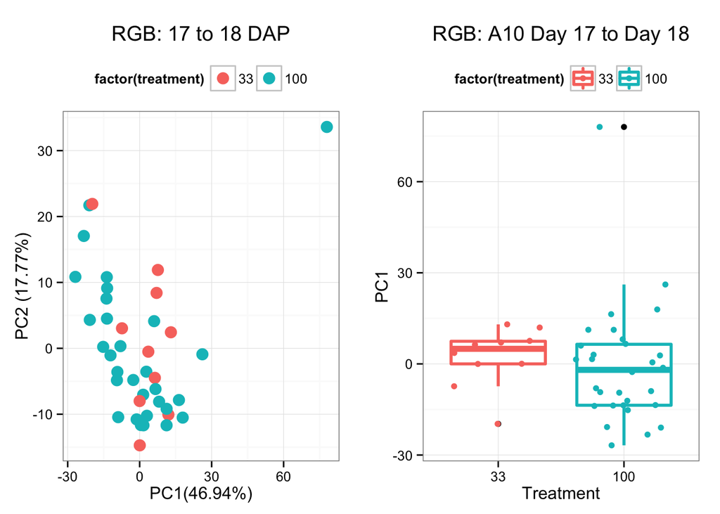

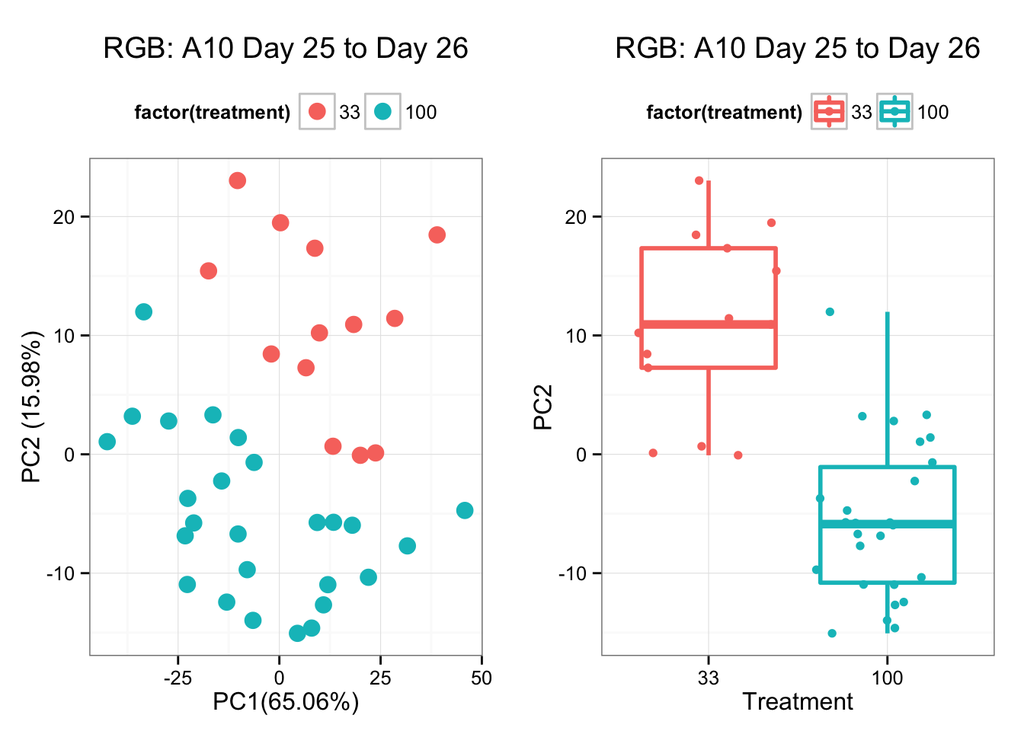

**Read in the HSV data**

```r
hue1<-read.table("vis_signal_hue_02-10-2015_16:41:15.txt", sep=',', header=TRUE)
saturation1<-read.table("vis_signal_saturation_02-10-2015_16:41:15.txt", sep=',', header=TRUE)
value1<-read.table("vis_signal_value_02-10-2015_16:41:15.txt",sep=',', header=TRUE)

format_data=function(data){
  # Treatment column
  data$treatment <- NA
  data$treatment[grep("AA", data$barcode)] <- 100
  data$treatment[grep("AB", data$barcode)] <- 0
  data$treatment[grep("AC", data$barcode)] <- 0
  data$treatment[grep("AD", data$barcode)] <- 33
  data$treatment[grep("AE", data$barcode)] <- 66

  data$genotype <- NA
  data$genotype[grep("p1", data$barcode)] <- 'A10'
  data$genotype[grep("p2", data$barcode)] <- 'B100'
  data$genotype[grep("r1", data$barcode)] <- 'R20'
  data$genotype[grep("r2", data$barcode)] <- 'R70'
  data$genotype[grep("r3", data$barcode)] <- 'R98'
  data$genotype[grep("r4", data$barcode)] <- 'R102'
  data$genotype[grep("r5", data$barcode)] <- 'R128'
  data$genotype[grep("r6", data$barcode)] <- 'R133'
  data$genotype[grep("r7", data$barcode)] <- 'R161'
  data$genotype[grep("r8", data$barcode)] <- 'R187'

  data=data[grep('000A',data$barcode, invert=TRUE),]

  return(data)
}

hue1<-format_data(hue1)
saturation1<-format_data(saturation1)
value1<-format_data(value1)
h<-as.data.frame(hue1)
s<-as.data.frame(saturation1)
v<-as.data.frame(value1)
hs1<-merge(h,s,by=c("date_time","frame","barcode", "treatment","genotype","day"))
hsv2<-merge(hs1,v, by=c("date_time","frame","barcode", "treatment","genotype", "day"))
hsv1=subset(hsv2, select=-c(day, date_time, frame, barcode, treatment, genotype))

hsv_data<-data.frame(hsv2=I(as.matrix(hsv1)),treatment=hsv2$treatment,genotype=hsv2$genotype,date_time=hsv2$date_time, day=as.integer(hsv2$day))
```

**Read in the shapes data and merge it with the HSV data**

```r
shapes_table<-read.table("vis_snapshots.txt",sep='\t', header=TRUE)
shapes_table$barcode=shapes_table$plant_id
shapes_table$date_time=shapes_table$datetime

hsv_shapes<-merge(hsv2,shapes_table,by=c("date_time","barcode"))
hsv_shapes$day=as.integer(hsv_shapes$day)
```

**Subset the shape-HSV data**

```r
#Day 6 and 7 of the experiment is day 17 and 18 after planting
hsv_day17_18<-hsv_shapes[(hsv_shapes$treatment==100|hsv_shapes$treatment==33)& (hsv_shapes$genotype=='A10') & (hsv_shapes$day==6 |hsv_shapes$day==7),]
#Day 14 and 15 of the experiment is day 14 and 15 after planting
hsv_day25_26<-hsv_shapes[(hsv_shapes$treatment==100|hsv_shapes$treatment==33)& (hsv_shapes$genotype=='A10') & (hsv_shapes$day==14 |hsv_shapes$day==15),]
```

**PCA on 17-18 DAP HSV data**

```r
hsv_day17_18_channel=pca_format(hsv_day17_18)
hsv_day17_18_data=pca_nonzero(hsv_day17_18_channel)
hsv_day17_18_pca=go_pca(hsv_day17_18_data)
summary(hsv_day17_18_pca)
```

```
## Importance of components:
##                            PC1     PC2     PC3    PC4    PC5     PC6
## Standard deviation     12.1125 10.7030 6.84171 5.9190 5.3812 3.78857
## Proportion of Variance  0.2994  0.2338 0.09553 0.0715 0.0591 0.02929
## Cumulative Proportion   0.2994  0.5332 0.62872 0.7002 0.7593 0.78861
##                            PC7     PC8     PC9    PC10   PC11    PC12
## Standard deviation     3.55636 3.15958 2.92935 2.80340 2.5817 2.50787
## Proportion of Variance 0.02581 0.02037 0.01751 0.01604 0.0136 0.01284
## Cumulative Proportion  0.81442 0.83480 0.85231 0.86835 0.8820 0.89478
##                           PC13    PC14    PC15    PC16    PC17    PC18
## Standard deviation     2.29687 2.20113 2.03323 1.98701 1.76056 1.68007
## Proportion of Variance 0.01077 0.00989 0.00844 0.00806 0.00633 0.00576
## Cumulative Proportion  0.90555 0.91544 0.92388 0.93193 0.93826 0.94402
##                           PC19    PC20    PC21    PC22    PC23    PC24
## Standard deviation     1.58171 1.52894 1.48769 1.44773 1.36764 1.35633
## Proportion of Variance 0.00511 0.00477 0.00452 0.00428 0.00382 0.00375
## Cumulative Proportion  0.94913 0.95390 0.95841 0.96269 0.96651 0.97026
##                           PC25    PC26    PC27    PC28    PC29    PC30
## Standard deviation     1.32460 1.22510 1.17701 1.11261 1.08016 0.98674
## Proportion of Variance 0.00358 0.00306 0.00283 0.00253 0.00238 0.00199
## Cumulative Proportion  0.97384 0.97691 0.97973 0.98226 0.98464 0.98663
##                           PC31   PC32    PC33    PC34    PC35    PC36
## Standard deviation     0.97630 0.9395 0.91101 0.89315 0.84930 0.83851
## Proportion of Variance 0.00195 0.0018 0.00169 0.00163 0.00147 0.00143
## Cumulative Proportion  0.98857 0.9904 0.99207 0.99370 0.99517 0.99660
##                           PC37    PC38    PC39      PC40
## Standard deviation     0.79006 0.77799 0.65974 5.735e-15
## Proportion of Variance 0.00127 0.00124 0.00089 0.000e+00
## Cumulative Proportion  0.99788 0.99911 1.00000 1.000e+00
```

```r
hsv_day17_18_scores<-as.data.frame(hsv_day17_18_pca$x)
hsv_day17_18_scores$treatment=hsv_day17_18$treatment
hsv_day17_18_scores$genotype=hsv_day17_18$genotype
hsv_day17_18_scores$date_time=hsv_day17_18$date_time
hsv_day17_18_scores$day=hsv_day17_18$day
hsv_day17_18_scores$barcode=hsv_day17_18$barcode
hsv_day17_18_scores$sv_area=hsv_day17_18$sv_area
hsv_day17_18_scores$height_above_bound=hsv_day17_18$height_above_bound

cor.test(hsv_day17_18_scores$treatment, hsv_day17_18_scores$PC1, method="spearman")
```

```
##
##  Spearman's rank correlation rho
##
## data:  hsv_day17_18_scores$treatment and hsv_day17_18_scores$PC1
## S = 9646.983, p-value = 0.5597
## alternative hypothesis: true rho is not equal to 0
## sample estimates:
##       rho
## 0.0950297
```

```r
cor.test(hsv_day17_18_scores$treatment, hsv_day17_18_scores$PC2, method="spearman")
```

```
##
##  Spearman's rank correlation rho
##
## data:  hsv_day17_18_scores$treatment and hsv_day17_18_scores$PC2
## S = 11459.75, p-value = 0.6454
## alternative hypothesis: true rho is not equal to 0
## sample estimates:
##         rho
## -0.07502345
```

```r
hsv17_18_treatment<-data.frame(hsv=I(as.matrix(hsv_day17_18_channel)),treatment=hsv_day17_18$treatment,genotype=hsv_day17_18$genotype,date_time=hsv_day17_18$date_time, day=hsv_day17_18$day)
hsv_a10_17_18_treatment<-pcr(treatment~hsv,data=hsv17_18_treatment)
summary(hsv_a10_17_18_treatment)
```

```
## Data:    X dimension: 40 768
##  Y dimension: 40 1
## Fit method: svdpc
## Number of components considered: 39
## TRAINING: % variance explained
##             1 comps  2 comps  3 comps  4 comps  5 comps  6 comps  7 comps
## X          58.23926  77.5882  84.9621   88.520   91.342   93.226    94.63
## treatment   0.08276   0.6894   0.9846    1.052    1.053    6.902     8.61
##            8 comps  9 comps  10 comps  11 comps  12 comps  13 comps
## X           95.535    96.23     96.83     97.39     97.79     98.11
## treatment    9.508    11.47     12.23     23.27     24.47     24.47
##            14 comps  15 comps  16 comps  17 comps  18 comps  19 comps
## X             98.41     98.63     98.84     99.04     99.19     99.31
## treatment     38.06     38.24     40.91     41.73     41.87     45.84
##            20 comps  21 comps  22 comps  23 comps  24 comps  25 comps
## X             99.42     99.51     99.58     99.64     99.68     99.73
## treatment     57.67     57.77     61.46     63.69     63.88     64.24
##            26 comps  27 comps  28 comps  29 comps  30 comps  31 comps
## X             99.77     99.81     99.84     99.86     99.89     99.90
## treatment     64.77     65.00     85.42     88.61     90.83     90.96
##            32 comps  33 comps  34 comps  35 comps  36 comps  37 comps
## X             99.92     99.94     99.95     99.96     99.97     99.99
## treatment     91.99     92.02     92.59     93.14     93.84     93.84
##            38 comps  39 comps
## X             99.99       100
## treatment     99.34       100
```

**PCA on 25-16 DAP HSV data**

```r
############# Day  25 and 26 after planting for A10 ###############

hsv_day25_26_channel=pca_format(hsv_day25_26)
hsv_day25_26_data=pca_nonzero(hsv_day25_26_channel)
hsv_day25_26_pca=go_pca(hsv_day25_26_data)
summary(hsv_day25_26_pca)
```

```
## Importance of components:
##                            PC1     PC2     PC3     PC4     PC5     PC6
## Standard deviation     14.9681 12.6303 5.34805 4.14884 3.46401 3.21063
## Proportion of Variance  0.4454  0.3171 0.05686 0.03422 0.02386 0.02049
## Cumulative Proportion   0.4454  0.7626 0.81942 0.85364 0.87750 0.89799
##                            PC7     PC8     PC9    PC10    PC11    PC12
## Standard deviation     2.75963 2.29337 1.88622 1.81562 1.77405 1.73105
## Proportion of Variance 0.01514 0.01046 0.00707 0.00655 0.00626 0.00596
## Cumulative Proportion  0.91313 0.92359 0.93066 0.93721 0.94347 0.94943
##                           PC13    PC14    PC15    PC16    PC17    PC18
## Standard deviation     1.57294 1.51033 1.46589 1.41673 1.38009 1.23186
## Proportion of Variance 0.00492 0.00454 0.00427 0.00399 0.00379 0.00302
## Cumulative Proportion  0.95435 0.95888 0.96315 0.96715 0.97093 0.97395
##                           PC19    PC20   PC21    PC22    PC23    PC24
## Standard deviation     1.11921 1.07409 1.0525 0.99631 0.95453 0.94823
## Proportion of Variance 0.00249 0.00229 0.0022 0.00197 0.00181 0.00179
## Cumulative Proportion  0.97644 0.97873 0.9809 0.98291 0.98472 0.98651
##                           PC25    PC26    PC27    PC28    PC29    PC30
## Standard deviation     0.88670 0.86264 0.81153 0.78799 0.76297 0.72257
## Proportion of Variance 0.00156 0.00148 0.00131 0.00123 0.00116 0.00104
## Cumulative Proportion  0.98807 0.98955 0.99086 0.99209 0.99325 0.99429
##                           PC31    PC32    PC33    PC34    PC35    PC36
## Standard deviation     0.68712 0.65595 0.63232 0.61693 0.58317 0.57727
## Proportion of Variance 0.00094 0.00086 0.00079 0.00076 0.00068 0.00066
## Cumulative Proportion  0.99523 0.99608 0.99688 0.99763 0.99831 0.99897
##                           PC37    PC38      PC39
## Standard deviation     0.52492 0.49092 6.647e-15
## Proportion of Variance 0.00055 0.00048 0.000e+00
## Cumulative Proportion  0.99952 1.00000 1.000e+00
```

```r
hsv_day25_26_scores<-as.data.frame(hsv_day25_26_pca$x)
hsv_day25_26_scores$treatment=hsv_day25_26$treatment
hsv_day25_26_scores$genotype=hsv_day25_26$genotype
hsv_day25_26_scores$date_time=hsv_day25_26$date_time
hsv_day25_26_scores$day=hsv_day25_26$day
hsv_day25_26_scores$barcode=hsv_day25_26$barcode
hsv_day25_26_scores$sv_area=hsv_day25_26$sv_area
hsv_day25_26_scores$height_above_bound=hsv_day25_26$height_above_bound

cor.test(hsv_day25_26_scores$treatment, hsv_day25_26_scores$PC1, method="spearman")
```

```
##
##  Spearman's rank correlation rho
##
## data:  hsv_day25_26_scores$treatment and hsv_day25_26_scores$PC1
## S = 6298.799, p-value = 0.02335
## alternative hypothesis: true rho is not equal to 0
## sample estimates:
##       rho
## 0.3624697
```

```r
cor.test(hsv_day25_26_scores$treatment, hsv_day25_26_scores$PC2, method="spearman")
```

```
##
##  Spearman's rank correlation rho
##
## data:  hsv_day25_26_scores$treatment and hsv_day25_26_scores$PC2
## S = 2096.857, p-value = 2.665e-09
## alternative hypothesis: true rho is not equal to 0
## sample estimates:
##       rho
## 0.7877675
```

```r
hsv_25_26_shape<-data.frame(hsv=I(as.matrix(hsv_day25_26_channel)),treatment=hsv_day25_26$treatment,genotype=hsv_day25_26$genotype,date_time=hsv_day25_26$date_time, day=hsv_day25_26$day, sv_area=hsv_day25_26$sv_area)
hsv_a10_25_26_treatment<-pcr(treatment~hsv,data=hsv_25_26_shape)
summary(hsv_a10_25_26_treatment)
```

```
## Data:    X dimension: 39 768
##  Y dimension: 39 1
## Fit method: svdpc
## Number of components considered: 38
## TRAINING: % variance explained
##            1 comps  2 comps  3 comps  4 comps  5 comps  6 comps  7 comps
## X          57.7471    87.67    91.62    94.29    96.18    97.05    97.71
## treatment   0.0185    69.12    70.87    70.88    73.80    74.17    84.99
##            8 comps  9 comps  10 comps  11 comps  12 comps  13 comps
## X            98.16    98.55     98.79     99.01     99.17     99.30
## treatment    85.76    85.97     86.57     87.19     87.82     87.85
##            14 comps  15 comps  16 comps  17 comps  18 comps  19 comps
## X             99.42     99.49     99.55     99.61     99.66     99.71
## treatment     88.13     88.41     89.71     89.73     89.95     89.95
##            20 comps  21 comps  22 comps  23 comps  24 comps  25 comps
## X             99.74     99.78     99.81     99.83     99.85     99.87
## treatment     91.73     92.47     92.72     93.00     93.03     93.14
##            26 comps  27 comps  28 comps  29 comps  30 comps  31 comps
## X             99.89     99.90     99.92     99.93     99.94     99.95
## treatment     93.65     95.52     96.99     97.22     97.40     97.85
##            32 comps  33 comps  34 comps  35 comps  36 comps  37 comps
## X             99.96     99.97     99.98     99.98     99.99    100.00
## treatment     98.73     98.84     98.97     99.10     99.15     99.87
##            38 comps
## X               100
## treatment       100
```

# Plot 17-18 DAP and 25-26 DAP HSV data for A10

**The interpretation of HSV results is consistent with RGB data. Color 25-26 DAP can be used to distinguish watering treatments but is not an earlier indication of water limitation than biomass 17-18 DAP**

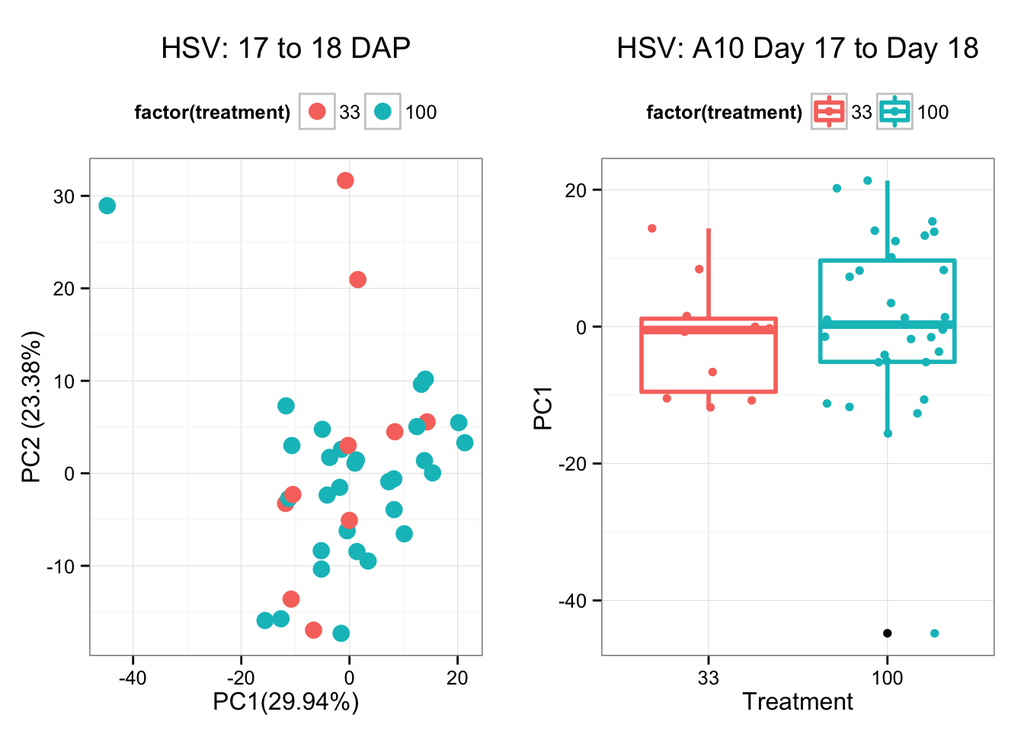

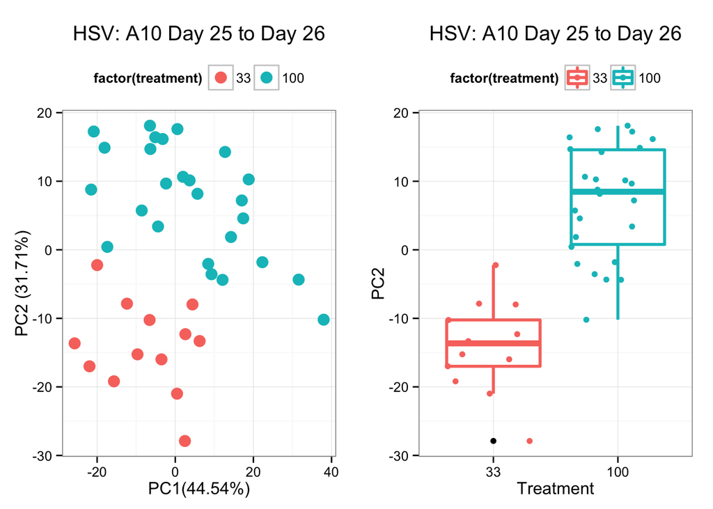

# PC1 and PC2 correlation between RGB and HSV

```r
cor.test(day17_18_scores$PC1, hsv_day17_18_scores$PC1, method="spearman")
```

```
##
##  Spearman's rank correlation rho
##
## data:  day17_18_scores$PC1 and hsv_day17_18_scores$PC1
## S = 19970, p-value < 2.2e-16
## alternative hypothesis: true rho is not equal to 0
## sample estimates:
##        rho
## -0.8733583
```

```r
cor.test(day17_18_scores$PC2, hsv_day17_18_scores$PC2, method="spearman")
```

```
##
##  Spearman's rank correlation rho
##
## data:  day17_18_scores$PC2 and hsv_day17_18_scores$PC2
## S = 5012, p-value = 0.0005296
## alternative hypothesis: true rho is not equal to 0
## sample estimates:
##       rho
## 0.5298311
```

```r
cor.test(day25_26_scores$PC1, hsv_day25_26_scores$PC1, method="spearman")
```

```
##
##  Spearman's rank correlation rho
##
## data:  day25_26_scores$PC1 and hsv_day25_26_scores$PC1
## S = 3588, p-value = 2.052e-05
## alternative hypothesis: true rho is not equal to 0
## sample estimates:
##       rho
## 0.6368421
```

```r
cor.test(day25_26_scores$PC2, hsv_day25_26_scores$PC2, method="spearman")
```

```
##
##  Spearman's rank correlation rho
##
## data:  day25_26_scores$PC2 and hsv_day25_26_scores$PC2
## S = 15374, p-value = 0.0002993
## alternative hypothesis: true rho is not equal to 0
## sample estimates:
##        rho
## -0.5560729
```

**Read in the LAB data**

```r
lightness1<-read.table("vis_signal_lightness_02-10-2015_16:49:44.txt", sep=',', header=TRUE)
gm1<-read.table("vis_signal_green-magenta_02-10-2015_16:49:44.txt", sep=',', header=TRUE)
by1<-read.table("vis_signal_blue-yellow_02-10-2015_16:49:44.txt",sep=',', header=TRUE)

format_data=function(data){
  # Treatment column
  data$treatment <- NA
  data$treatment[grep("AA", data$barcode)] <- 100
  data$treatment[grep("AB", data$barcode)] <- 0
  data$treatment[grep("AC", data$barcode)] <- 0
  data$treatment[grep("AD", data$barcode)] <- 33
  data$treatment[grep("AE", data$barcode)] <- 66

  data$genotype <- NA
  data$genotype[grep("p1", data$barcode)] <- 'A10'
  data$genotype[grep("p2", data$barcode)] <- 'B100'
  data$genotype[grep("r1", data$barcode)] <- 'R20'
  data$genotype[grep("r2", data$barcode)] <- 'R70'
  data$genotype[grep("r3", data$barcode)] <- 'R98'
  data$genotype[grep("r4", data$barcode)] <- 'R102'
  data$genotype[grep("r5", data$barcode)] <- 'R128'
  data$genotype[grep("r6", data$barcode)] <- 'R133'
  data$genotype[grep("r7", data$barcode)] <- 'R161'
  data$genotype[grep("r8", data$barcode)] <- 'R187'

  data=data[grep('000A',data$barcode, invert=TRUE),]

  return(data)
}

lightness1<-format_data(lightness1)
gm1<-format_data(gm1)
by1<-format_data(by1)
l<-as.data.frame(lightness1)
gm<-as.data.frame(gm1)
by<-as.data.frame(by1)
la1<-merge(l,gm,by=c("date_time","frame","barcode", "treatment","genotype","day"))
lab2<-merge(la1,by, by=c("date_time","frame","barcode", "treatment","genotype", "day"))
lab1=subset(lab2, select=-c(day, date_time, frame, barcode, treatment, genotype))

lab_data<-data.frame(lab2=I(as.matrix(lab1)),treatment=lab2$treatment,genotype=lab2$genotype,date_time=lab2$date_time, day=as.integer(lab2$day))
```

**Read in the shapes data and merge it with the LAB data**

```r
shapes_table<-read.table("vis_snapshots.txt",sep='\t', header=TRUE)
shapes_table$barcode=shapes_table$plant_id
shapes_table$date_time=shapes_table$datetime

lab_shapes<-merge(lab2,shapes_table,by=c("date_time","barcode"))
lab_shapes$day=as.integer(lab_shapes$day)
```

**Subset the shape-LAB data**

```r
#Day 6 and 7 of the experiment is day 17 and 18 after planting
lab_day17_18<-lab_shapes[(lab_shapes$treatment==100|lab_shapes$treatment==33)& (lab_shapes$genotype=='A10') & (lab_shapes$day==6 |lab_shapes$day==7),]
#Day 14 and 15 of the experiment is day 14 and 15 after planting
lab_day25_26<-lab_shapes[(lab_shapes$treatment==100|lab_shapes$treatment==33)& (lab_shapes$genotype=='A10') & (lab_shapes$day==14 |lab_shapes$day==15),]
```

**PCA on 17-18 DAP LAB data**

```r
lab_day17_18_channel=pca_format(lab_day17_18)
lab_day17_18_data=pca_nonzero(lab_day17_18_channel)
lab_day17_18_pca=go_pca(lab_day17_18_data)
summary(lab_day17_18_pca)
```

```
## Importance of components:
##                            PC1    PC2    PC3     PC4     PC5     PC6
## Standard deviation     10.9794 9.2472 6.1442 5.45402 3.86625 3.19072
## Proportion of Variance  0.3285 0.2330 0.1029 0.08105 0.04073 0.02774
## Cumulative Proportion   0.3285 0.5615 0.6643 0.74538 0.78611 0.81385
##                            PC7     PC8     PC9    PC10    PC11    PC12
## Standard deviation     2.96238 2.83280 2.57281 2.44934 2.09603 1.98801
## Proportion of Variance 0.02391 0.02187 0.01804 0.01635 0.01197 0.01077
## Cumulative Proportion  0.83777 0.85963 0.87767 0.89402 0.90599 0.91676
##                           PC13    PC14    PC15    PC16    PC17    PC18
## Standard deviation     1.86490 1.71999 1.54952 1.53605 1.47310 1.34639
## Proportion of Variance 0.00948 0.00806 0.00654 0.00643 0.00591 0.00494
## Cumulative Proportion  0.92623 0.93429 0.94084 0.94726 0.95318 0.95812
##                          PC19    PC20    PC21    PC22    PC23    PC24
## Standard deviation     1.2857 1.21944 1.20823 1.10881 1.05883 1.00702
## Proportion of Variance 0.0045 0.00405 0.00398 0.00335 0.00305 0.00276
## Cumulative Proportion  0.9626 0.96667 0.97065 0.97400 0.97706 0.97982
##                           PC25    PC26    PC27    PC28    PC29    PC30
## Standard deviation     0.95600 0.91284 0.85475 0.80943 0.78326 0.74730
## Proportion of Variance 0.00249 0.00227 0.00199 0.00179 0.00167 0.00152
## Cumulative Proportion  0.98231 0.98458 0.98657 0.98835 0.99003 0.99155
##                           PC31   PC32    PC33    PC34    PC35   PC36
## Standard deviation     0.70775 0.6916 0.65923 0.59656 0.58312 0.5412
## Proportion of Variance 0.00136 0.0013 0.00118 0.00097 0.00093 0.0008
## Cumulative Proportion  0.99291 0.9942 0.99540 0.99637 0.99730 0.9981
##                          PC37    PC38    PC39      PC40
## Standard deviation     0.5061 0.47962 0.46152 4.876e-15
## Proportion of Variance 0.0007 0.00063 0.00058 0.000e+00
## Cumulative Proportion  0.9988 0.99942 1.00000 1.000e+00
```

```r
lab_day17_18_scores<-as.data.frame(lab_day17_18_pca$x)
lab_day17_18_scores$treatment=lab_day17_18$treatment
lab_day17_18_scores$genotype=lab_day17_18$genotype
lab_day17_18_scores$date_time=lab_day17_18$date_time
lab_day17_18_scores$day=lab_day17_18$day
lab_day17_18_scores$barcode=lab_day17_18$barcode
lab_day17_18_scores$sv_area=lab_day17_18$sv_area
lab_day17_18_scores$height_above_bound=lab_day17_18$height_above_bound

cor.test(lab_day17_18_scores$treatment, lab_day17_18_scores$PC1, method="spearman")
```

```
##
##  Spearman's rank correlation rho
##
## data:  lab_day17_18_scores$treatment and lab_day17_18_scores$PC1
## S = 11832.97, p-value = 0.4991
## alternative hypothesis: true rho is not equal to 0
## sample estimates:
##        rho
## -0.1100344
```

```r
cor.test(lab_day17_18_scores$treatment, lab_day17_18_scores$PC2, method="spearman")
```

```
##
##  Spearman's rank correlation rho
##
## data:  lab_day17_18_scores$treatment and lab_day17_18_scores$PC2
## S = 9380.4, p-value = 0.4606
## alternative hypothesis: true rho is not equal to 0
## sample estimates:
##       rho
## 0.1200375
```

```r
lab17_18_treatment<-data.frame(lab=I(as.matrix(lab_day17_18_channel)),treatment=lab_day17_18$treatment,genotype=lab_day17_18$genotype,date_time=lab_day17_18$date_time, day=lab_day17_18$day)
lab_a10_17_18_treatment<-pcr(treatment~lab,data=lab17_18_treatment)
summary(lab_a10_17_18_treatment)
```

```
## Data:    X dimension: 40 768
##  Y dimension: 40 1
## Fit method: svdpc
## Number of components considered: 39
## TRAINING: % variance explained
##            1 comps  2 comps  3 comps  4 comps  5 comps  6 comps  7 comps
## X          54.7402   73.763   81.850   87.661   90.916    92.86    94.45
## treatment   0.9587    4.851    5.639    7.156    7.163    16.64    19.83
##            8 comps  9 comps  10 comps  11 comps  12 comps  13 comps
## X            95.55    96.61     97.13     97.57     97.91     98.24
## treatment    19.85    20.01     25.54     25.92     30.54     30.75
##            14 comps  15 comps  16 comps  17 comps  18 comps  19 comps
## X             98.47     98.68     98.86     99.02     99.17     99.29
## treatment     41.72     41.72     42.32     42.32     43.42     50.75
##            20 comps  21 comps  22 comps  23 comps  24 comps  25 comps
## X             99.40      99.5     99.57     99.64     99.69     99.74
## treatment     63.08      63.7     63.95     64.64     64.65     69.12
##            26 comps  27 comps  28 comps  29 comps  30 comps  31 comps
## X             99.79     99.82     99.85     99.88     99.90     99.92
## treatment     73.56     73.69     74.60     86.28     87.94     88.11
##            32 comps  33 comps  34 comps  35 comps  36 comps  37 comps
## X             99.93     99.95     99.96     99.97     99.98     99.99
## treatment     96.37     96.55     96.55     97.91     98.79     99.93
##            38 comps  39 comps
## X             99.99       100
## treatment     99.97       100
```

```r
############# Day  25 and 26 after planting for A10 ###############

lab_day25_26_channel=pca_format(lab_day25_26)
lab_day25_26_data=pca_nonzero(lab_day25_26_channel)
lab_day25_26_pca=go_pca(lab_day25_26_data)
summary(lab_day25_26_pca)
```

```
## Importance of components:
##                            PC1    PC2     PC3     PC4     PC5     PC6
## Standard deviation     15.0434 8.0770 5.41859 3.68820 3.30829 2.78338
## Proportion of Variance  0.5602 0.1615 0.07268 0.03367 0.02709 0.01918
## Cumulative Proportion   0.5602 0.7216 0.79431 0.82798 0.85508 0.87425
##                            PC7     PC8     PC9    PC10    PC11    PC12
## Standard deviation     2.48487 2.23930 1.98526 1.92350 1.80343 1.70037
## Proportion of Variance 0.01528 0.01241 0.00976 0.00916 0.00805 0.00716
## Cumulative Proportion  0.88954 0.90195 0.91170 0.92086 0.92891 0.93607
##                          PC13    PC14    PC15   PC16   PC17    PC18
## Standard deviation     1.5308 1.45741 1.38688 1.3488 1.2868 1.26536
## Proportion of Variance 0.0058 0.00526 0.00476 0.0045 0.0041 0.00396
## Cumulative Proportion  0.9419 0.94713 0.95189 0.9564 0.9605 0.96445
##                           PC19    PC20    PC21    PC22    PC23    PC24
## Standard deviation     1.21170 1.19140 1.15061 1.11463 1.03434 0.98048
## Proportion of Variance 0.00363 0.00351 0.00328 0.00308 0.00265 0.00238
## Cumulative Proportion  0.96809 0.97160 0.97488 0.97795 0.98060 0.98298
##                           PC25    PC26    PC27    PC28    PC29    PC30
## Standard deviation     0.93137 0.86253 0.83775 0.81878 0.78707 0.74315
## Proportion of Variance 0.00215 0.00184 0.00174 0.00166 0.00153 0.00137
## Cumulative Proportion  0.98513 0.98697 0.98871 0.99037 0.99190 0.99327
##                           PC31    PC32    PC33    PC34   PC35    PC36
## Standard deviation     0.70253 0.67874 0.62326 0.59106 0.5688 0.54608
## Proportion of Variance 0.00122 0.00114 0.00096 0.00086 0.0008 0.00074
## Cumulative Proportion  0.99449 0.99563 0.99659 0.99745 0.9983 0.99899
##                           PC37    PC38      PC39
## Standard deviation     0.48466 0.41448 6.681e-15
## Proportion of Variance 0.00058 0.00043 0.000e+00
## Cumulative Proportion  0.99957 1.00000 1.000e+00
```

```r
lab_day25_26_scores<-as.data.frame(lab_day25_26_pca$x)
lab_day25_26_scores$treatment=lab_day25_26$treatment
lab_day25_26_scores$genotype=lab_day25_26$genotype
lab_day25_26_scores$date_time=lab_day25_26$date_time
lab_day25_26_scores$day=lab_day25_26$day
lab_day25_26_scores$barcode=lab_day25_26$barcode
lab_day25_26_scores$sv_area=lab_day25_26$sv_area
lab_day25_26_scores$height_above_bound=lab_day25_26$height_above_bound

cor.test(lab_day25_26_scores$treatment, lab_day25_26_scores$PC1, method="spearman")
```

```
##
##  Spearman's rank correlation rho
##
## data:  lab_day25_26_scores$treatment and lab_day25_26_scores$PC1
## S = 9402.506, p-value = 0.7702
## alternative hypothesis: true rho is not equal to 0
## sample estimates:
##       rho
## 0.0483293
```

```r
cor.test(lab_day25_26_scores$treatment, lab_day25_26_scores$PC2, method="spearman")
```

```
##
##  Spearman's rank correlation rho
##
## data:  lab_day25_26_scores$treatment and lab_day25_26_scores$PC2
## S = 16994.65, p-value = 2.37e-07
## alternative hypothesis: true rho is not equal to 0
## sample estimates:
##        rho
## -0.7201065
```

```r
lab_25_26_shape<-data.frame(lab=I(as.matrix(lab_day25_26_channel)),treatment=lab_day25_26$treatment,genotype=lab_day25_26$genotype,date_time=lab_day25_26$date_time, day=lab_day25_26$day, sv_area=lab_day25_26$sv_area)
lab_a10_25_26_treatment<-pcr(treatment~lab,data=lab_25_26_shape)
summary(lab_a10_25_26_treatment)
```

```
## Data:    X dimension: 39 768
##  Y dimension: 39 1
## Fit method: svdpc
## Number of components considered: 38
## TRAINING: % variance explained
##            1 comps  2 comps  3 comps  4 comps  5 comps  6 comps  7 comps
## X            74.30    90.76    94.85    96.89    97.58    98.04    98.49
## treatment    26.98    54.88    68.00    68.05    68.17    70.69    72.06
##            8 comps  9 comps  10 comps  11 comps  12 comps  13 comps
## X            98.77    98.98     99.17     99.32     99.45     99.56
## treatment    73.30    73.53     73.80     89.76     90.11     90.50
##            14 comps  15 comps  16 comps  17 comps  18 comps  19 comps
## X             99.63     99.69     99.74     99.78     99.80     99.83
## treatment     90.52     90.55     90.55     90.77     90.82     90.82
##            20 comps  21 comps  22 comps  23 comps  24 comps  25 comps
## X             99.85     99.87     99.89     99.90     99.91     99.93
## treatment     92.86     92.97     93.23     93.87     94.16     94.71
##            26 comps  27 comps  28 comps  29 comps  30 comps  31 comps
## X             99.94     99.95     99.95     99.96     99.97     99.97
## treatment     94.88     95.04     95.43     95.44     96.09     96.53
##            32 comps  33 comps  34 comps  35 comps  36 comps  37 comps
## X             99.98     99.98     99.99     99.99     100.0    100.00
## treatment     97.55     97.56     97.57     98.35      99.3     99.99
##            38 comps
## X               100
## treatment       100
```

# Plot 17-18 DAP and 25-26 DAP LAB data for A10

**The interpretation of LAB results is consistent with RGB data. Color 25-26 DAP can be used to distinguish watering treatments but is not an earlier indication of water limitation than biomass 17-18 DAP**

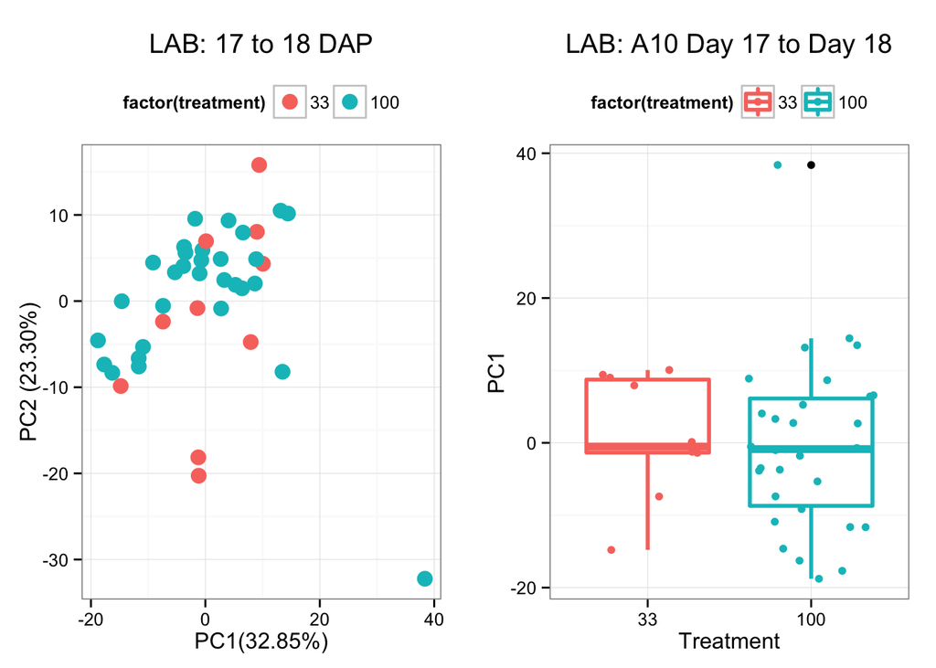

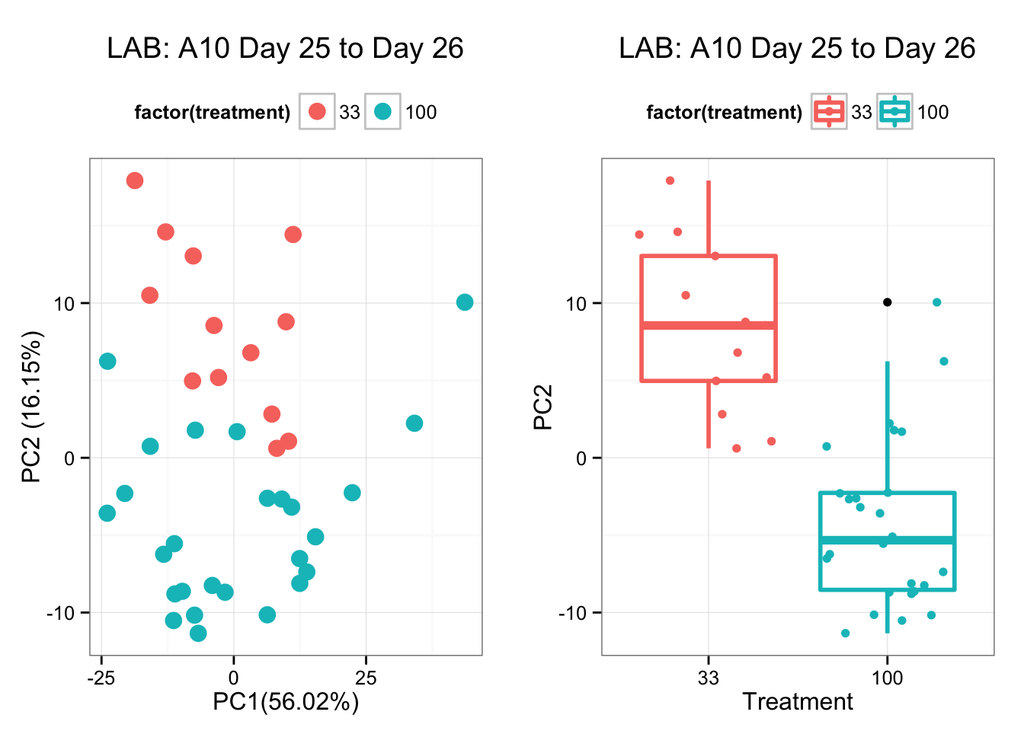

# PC1 and PC2 correlation between RGB and LAB

```r
cor.test(day17_18_scores$PC1, lab_day17_18_scores$PC1, method="spearman")
```

```
##
##  Spearman's rank correlation rho
##
## data:  day17_18_scores$PC1 and lab_day17_18_scores$PC1
## S = 1260, p-value < 2.2e-16
## alternative hypothesis: true rho is not equal to 0
## sample estimates:
##       rho
## 0.8818011
```

```r
cor.test(day17_18_scores$PC2, lab_day17_18_scores$PC2, method="spearman")
```

```
##
##  Spearman's rank correlation rho
##
## data:  day17_18_scores$PC2 and lab_day17_18_scores$PC2
## S = 19002, p-value = 7.947e-08
## alternative hypothesis: true rho is not equal to 0
## sample estimates:
##        rho
## -0.7825516
```

```r
cor.test(day25_26_scores$PC1, lab_day25_26_scores$PC1, method="spearman")
```

```
##
##  Spearman's rank correlation rho
##
## data:  day25_26_scores$PC1 and lab_day25_26_scores$PC1
## S = 1392, p-value < 2.2e-16
## alternative hypothesis: true rho is not equal to 0
## sample estimates:
##       rho
## 0.8591093
```

```r
cor.test(day25_26_scores$PC2, lab_day25_26_scores$PC2, method="spearman")
```

```
##
##  Spearman's rank correlation rho
##
## data:  day25_26_scores$PC2 and lab_day25_26_scores$PC2
## S = 1788, p-value = 2.144e-08
## alternative hypothesis: true rho is not equal to 0
## sample estimates:
##       rho
## 0.8190283
```